# ThrombinCL

# Notes for Analysing Thrombin Generation Curves

A help tab in the app summarises the main features of ThrombinCL version 0.5 and above. More details are presented below.

# The *Plots* tab

### Data Entry

A set of data is provided and is automatically read and analysed when the program starts. The thrombin generation curves can be explored to get a feel for using the various options discussed below. However, the main use for the program is to facilitate analysis of user data.

Time course data should be formated as a single column of time in column 1 followed by columns of absorbance data. The program detects the length and width of the data so there is no need to specify these dimensions. Data can be read as csv, csv2 (using , instead of . for the decimal point), txt or Excel files. These options are specified using the radio buttons in the left hand panel. It is also necessary to specify if the columns have header text (“Time”, well names “A1”, “A2”… etc), which is recommended.

**Note:** *it is important not to leave empty cells, incomplete columns or rows, or spaces in names of column headers in any data files. Gaps and spaces are the main reasons the program fails to read data or complete an analysis.*

Below is an example of a few rows of data to show how it should be formatted (and this is how it should appear in the *Raw data* tab).

| time | Ref_0.1pM | Ref_0.5pM | Ref_1pM | Ref_5pM | Ref_5pM.1 | PRP_0.1pM |
| --- | --- | --- | --- | --- | --- | --- |
| 0.59 | -0.09 | -0.06 | -0.19 | 0.06 | 0.63 | -0.09 |
| 0.93 | -0.19 | 0.06 | -0.06 | 0.76 | 2.78 | 0.1 |
| 1.26 | 0 | 0.19 | 0.57 | 2.21 | 11.18 | 0.1 |
| 1.6 | 0.1 | 0.5 | 1.2 | 6.94 | 34.35 | 0.1 |
| 1.93 | 0.1 | 0.76 | 1.51 | 16.3 | 72.67 | 0 |
| 2.26 | 0.13 | 0.82 | 2.33 | 29.19 | 118.5 | 0.06 |
| 2.6 | 0.06 | 1.13 | 4.34 | 45.01 | 164.4 | 0.19 |
| 2.93 | 0.25 | 1.31 | 7.55 | 62.02 | 203.6 | 0.13 |
| 3.27 | 0.5 | 1.81 | 11.9 | 79.15 | 230.8 | 0.31 |
| 3.6 | 0.5 | 2.82 | 17.53 | 95.87 | 243 | 0.38 |

### Plotting the data

The graphical output in the main panel of the opening page is organised by number of rows specified, using the *How many rows* numerical input box. The initiation point is selected using the *% for initiation* input box and determines where the lag time ends. The default is 0.1, which means the lag time is calculated at the point where there is a 10% increase in thrombin concentration above zero.

### Fitted Data and fitting options

You can choose to use the raw data you provide or fit a spline curve to your data to add more points. Fitted data are useful if your data points are sparse. However, the values for absorbance and time to selected clotting or lysis are calculated by the program from spline fits, so should be accurate whichever choice you make. The *Fittings options* boxes allow you to narrow down the range of interest for your set of curves and to decide how many points should be in that range, when *Fitted points* are selected. The newly adjusted data is also shown on the *Raw Data* tab.

### Adjust graphs

Options to adjust the x and y axes of the plots are provided as sliders. These options only affect the way the plots look on the right hand side of the page, they do not affect any calculations. The ranges selected here are also replicated in the plots of individual curves that are accessed in the *Curve* tab.

### Baseline options

Below the axis range sliders there are input options as radio buttons that dictate how the baseline will be set. The zero value selected will be the absorbance that equates to the beginning or end of the thrombin generation curves. The first option is for a global zero, which is specified by the adjacent numerical input. In this case all curves will have the same zero absorbance value.

A second option provided is to zero the curves at a starting absorbance value for each curve. The default value for the *nth absorbance* is 1, i.e. the first reading of each curve. Later points can be chosen by increasing the value in the *nth point* input box, for instance a point where all curves have returned to zero. In this case individual curves may have different zero values but they will all be selected at the same time point.

The 3rd option is to use the minimum absorbance value of each curve with the possibility to add an offset value using the slider below the radio buttons. In this case the zero absorbance can vary for each curve and will likely come from a different time point along the curve.

Some care is needed when using these option as the chosen zero affects several of the calculated results. The curves should be scrutinised to give authentic results and details of the chosen options recorded (the zeroed absorbance values can be selected for display in the *Results Table*). The method chosen to zero the curves (global, nth point or minimum with offset is also recorded in the *Settings* tab (see below). of The Results Table can display the absolute maximum absorbance or the absorbance above the baseline after subtraction of the chosen zero value.

### Results table

- **Column names:** Displays the header text in the data file in the specified arrangement
- **Chosen zero:** Displays whatever zero value has been selected for each curve
- **Time to initiation:** Time when thrombin reaches the selected % increase also known as lag time
- **Reading at initiation:** Thrombin concentration at the chosen initiation point
- **Reading at peak:** Thrombin concentraion at maximum of curve
- **Reading peak-zero:** Thrombin at peak with baseline subtracted
- **Time to Peak from zero:** Time to chosen maximum thrombin concentration from the start
- **Time initiation to peak:** Time between the selected initiation point and maximum thrombin concentrtion
- **Time to decay from zero:** Time from the start when thrombin concentration returns to value at initiation
- **Reading at decay:** Thrombin concentration at decay start (should be same as initiation value)
- **Time between initiation and decay:** Time between the initiation point and when the thrombin concentration returns to this level
- **Time peak to decay:** Time from the peak to the decay point
- **Time to tail:** Time from the start when thrombin concentration returns to zero
- **Time from initiation to tail:** Time between the initation point and return to zero thrombin
- **Area under the curve:** Thrombin produced overall, units of concentration x time
- **Time at max rate increase:** First derivative, time at maximum positive change
- **Time at max rate decrease:** First derivative, time at maximum negative change
- **Time at sign chance:** First derivative, time where change is zero (close to peak)

The options that are calculated from the first derivative transformations are susceptible to noise and should be used with care. First derivate plots are not shown on this tab but are available from the second tab, *Curve*.

The plots above the Results table shows graphically which selection is made as dashed lines, arrows or magenta lines for first derivative results.

Graphs and results table can be copied to the clipboard by highlighting and right-clicking using the mouse. If you download and run the ui.R and server.R files locally in RStudio, you can search for the line of code in the Results Table section of the server.R file that contains “clipboard” and remove the # from the beginning of the line. If this line of code is active, the contents of the table are automatically placed in the clipboard and can be pasted directly elsewhere for further analysis.

A set of curves

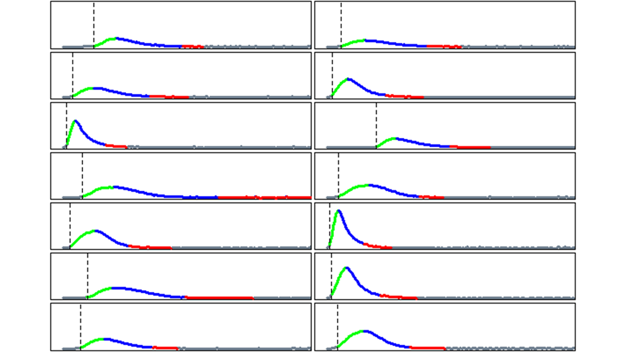

The corresponding output table

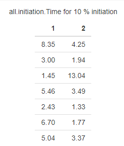

# The *Curve* tab

The curve tab allows the user to focus on a single clot lysis curve, which is selected from the box in the upper left corner. The plot includes lines corresponding to various analysis selections available. The radio buttons under **Selected Results** specify what is shown in the table below the graph - all results, or results from clotting or lysis sections of the curve only.

The first derivative button adds a first derivative plot to the graph and shows a results table including the time where there is maximum rate of absorbance increase; maximum rate of absorbance decrease; and the first time when there is a plateau (sign change between consecutive first derivative readings). As mentioned above, these results are susceptible to noise in the absorbance data and should be checked by careful visual inspection alongside the curves.

A single plot from the *Curve* tab

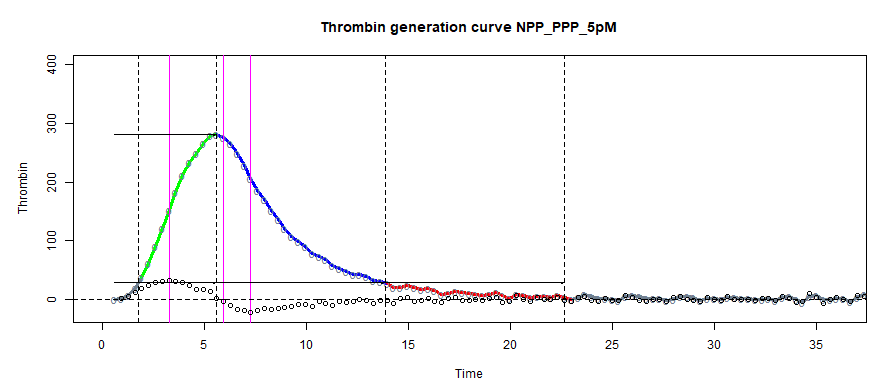

# The *All Results* tab

Here there is a table of all the values from each well for each parameter available. It is possible to click through pages of data using boxes at the foot of the page and to show data from start to end or in reverse.

# The *Raw Data* tab

On this tab the name of the data file loaded is shown and the time and absorbance data. If fitted curves have been generated, the new data will be displayed with the additional points.

# The *Explore* tab

This tab provides a simple opportunity to explore your results graphically. The default plot is a heatmap, so you can see patterns and extreme values for selected paramters. If a scatter plot is selected you can select what should be plotted on the x and y axis to investigate relationships between various parameters. Points can be identified by hovering over them with the mouse.

# The *Settings* tab

Here a table of settings is provided of all setting used in the analysis, which can be copied for future reference to aid reproducibility.

# The *Help* tab

The *Help* tab summarises these help notes and provides citation details.

R code, data and help files are available from: https://github.com/drclongstaff/Thrombin_Generation

More information and links may be found at http://www.nibsc.org/science_and_research/biotherapeutics/haemostasis/fibrinolysis.aspx